# Bernoulli and Binomial Distributions: The Math

Wednesday, October 13, 2021 @ 05:14 PM

## Before We Begin…

These slides are not meant to be standalone information. You should take notes to flesh out the contents. I recommend that you create an R Markdown document where you can combine information and code from the slides and your own additional notes and explorations to make connections.

**Related Materials**

- Appendix A of *Mathematical Statistics with Resampling and R, 2<sup>nd</sup> Ed.* (Review of Probability)
- DataCamp [Foundations of Probability in R](https://learn.datacamp.com/courses/foundations-of-probability-in-r)
- [Bernoulli and Binomial Distributions: `R` Code](https://stat-jet-asu.github.io/StatisticalDataAnalysis1/Slides/BinomialDistributionRCode.html) class slides

## Index

- Slides 02-03 — Materials & Index
- Slides 04-06 — Bernoulli Trials
- Slides 07-10 — Some Simple Simulations
- Slides 11-25 — Binomial Distribution Model
  - Slides 12-18 — Probability Mass Function (pmf)
  - Slides 19-21 — Cumulative Distribution Function (CDF)
  - Slides 22-25 — Tabulated and Graphical Representations
- Slides 26-28 — Expected Value (Mean) and Variance

## Bernoulli Trials

## What is a Bernoulli Trial?

A Bernoulli trial is a single random event that has two possible outcomes, often called “success” and “failure”.

A “success” is not necessarily a good/positive outcome, but it is the outcome of interest for a given problem.

Classic examples include a coin flip where a head is considered success and a tail is considered failure, or one roll of a standard 6-sided die where 1 is success and any other number is failure.

The Bernoulli model has a single parameter \(p\), where…

- \(p\) = probability of success
- \(q\) = probability of failure = \(1 - p\)

## Bernoulli as a Building Block

Other probability distributions, such as the binomial distribution and geometric distribution, are used to model the outcomes of sequences of Bernoulli trials (e.g., number of heads obtained in a sequence of 100 coin flips, or how many times we have to roll a 6-sided die to observe our first 1).

A necessary condition for the binomial and geometric random variables is that all trials are *independent* with constant chance of success \(p\) from trial to trial.

“Bernoulli trial” is named for noted Swiss mathematician [Jacob Bernoulli](https://mathshistory.st-andrews.ac.uk/Biographies/Bernoulli_Jacob/) (1654-1705), who made important advancements in probability theory, including an early version of the law of large numbers. Many appeared in his posthumously-published book [*Ars Conjectandi*](https://books.google.com/books?id=XPOf7STJ3y4C&pg=PP5#v=onepage&q&f=false) (*The Art of Conjecturing*, 1713).

## Some Simple Simulations

## Simulate One Coin Flip or One Die Roll

```r
coin <- c("head", "tail")   # create the coin model
sample(coin, size = 1)  # default equal probability
```

```
[1] "head"
```

```r
die <- 1:6   # create the die model integers 1 to 6
sample(die, size = 1)   # default equal probability
```

```
[1] 5
```

```r
# an unfair coin with a 70% chance of heads
sample(coin, size = 1, prob = c(0.7, 1 - 0.7))
```

```
[1] "tail"
```

## Simulate Multiple Trials with `sample()`

```r
flips <- sample(coin, size = 250, replace = TRUE)
```

```r
sum(flips == "head")   # number of heads in the sample
```

```
[1] 130
```

```r
mean(flips == "head")   # fraction of heads in the sample
```

```
[1] 0.52
```

```r
rolls <- sample(die, size = 250, replace = TRUE)
mean(rolls == 1)   # fraction of 1's in the sample
```

```
[1] 0.188
```

## The `prob` Package

The `prob` package includes functions for exploring probability. For example, `tosscoin()` produces all possible sequences of H and T for a given number of tosses (< 20).

```r
library(prob)
tosscoin(times = 3)
```

```
  toss1 toss2 toss3
1     H     H     H
2     T     H     H
3     H     T     H
4     T     T     H
5     H     H     T
6     T     H     T
7     H     T     T
8     T     T     T
```

## Binomial Distribution

## Probability Mass Function (pmf)

The binomial distribution is a discrete probability distribution. It mathematically models the *number of successes* in a sequence of independent Bernoulli trials. The probability for a given number of successes \(x\) is found using the *probability mass function* (pmf).

\[X \sim Bin(n,p)\]

\(x\) = number of successes = {0, 1, 2, …, \(n\)} = *sample space*  
\(n\) = number of trials  
\(p\) = probability of success on a single trial  
\(1 - p\) = probability of failure on a single trial

\[f(x) = P(X = x) = {n \choose x}p^x(1-p)^{n-x}\]

## Combinations of Objects

The expression \({n \choose x}\) is read as \(n\) choose \(x\). How many ways are there to choose a subset of \(x\) objects from a set of \(n\) objects if the specific order of the objects does not matter?

\[{n \choose x} = \frac{n!}{x!(n-x)!}\]

Consider the arrangements of coin flips we saw on a prior slide. How many ways are there to get exactly 2 heads in a sequence of 3 flips? We do not care *where* in the sequence they appear.

```r
choose(3, 2)   # syntax: choose(n, k)
```

```
[1] 3
```

Three of the eight possible sequences have 2 heads and 1 tail. This is true no matter the value of \(p\), barring the limiting cases where success is impossible (\(p = 0\)) or certain (\(p = 1\)).

| Toss 1 | Toss 2 | Toss 3 | Number of Heads |
| --- | --- | --- | --- |
| H | H | H | 3 |
| T | H | H | 2 |
| H | T | H | 2 |
| T | T | H | 1 |
| H | H | T | 2 |
| T | H | T | 1 |
| H | T | T | 1 |
| T | T | T | 0 |

The number of trials determines what is *possible*. The value of \(p\) determines what is *probable*, or how often things occur.

## Binomial Coefficient and “Choose”

Pascal’s triangle, named for French mathematician Blaise Pascal (1623-1662), is a representation of the binomial coefficient. Can you connect this to the table on the previous slide?

[figure not shown]

## What about the probability?

The rest of the pmf calculates probability for a single sequence.

\[p^x(1-p)^{n-x}\]

If a coin is fair, then the probability of flipping a head or a tail is the same (\(p = q = 0.5\)), and so the probability of any sequence of 3 flips is \(0.5 \times 0.5 \times 0.5 = 0.125\).

Suppose we have an unfair coin with a 70% chance of flipping a head (\(p = 0.7\)). What is the probability of any *one* sequence of 2 heads (and 1 tail) in 3 flips?

\[p \times p \times q = 0.7 \times 0.7 \times (1 - 0.7) = \] \[(0.7)^2(1-0.7)^{3-2} = (0.7)^2(0.3)^1 = 0.147\]

## Put It All Together

For a given number of successes \(x\) in a series of \(n\) independent Bernoulli trials with \(p\) chance of success for each trial, the pmf finds the probability of a single sequence with \(x\) successes and multiplies it by the number of possible sequences.

\[f(2) = P(X = 2) = {3 \choose 2}(0.7)^2(1 - 0.7)^{3 - 2} =\]

\[\frac{3!}{2!(3 - 2)!}(0.7)^2(0.3)^1 = 3 \times 0.147 = 0.441\]

For \(n = 3\) trials, we can have \(x = \{0, 1, 2, 3\}\). As a reminder, \(0! = 1\) by definition. Also, notice the pattern in the numerator and denominator factorials and exponents.

## For Three Flips of Our Biased Coin

\[P(X = 0) = \frac{3!}{0!(3 - 0)!}(0.7)^0(0.3)^{3-0} = 0.027\]

\[P(X = 1) = \frac{3!}{1!(3 - 1)!}(0.7)^1(0.3)^{3-1} = 0.189\]

\[P(X = 2) = \frac{3!}{2!(3 - 2)!}(0.7)^2(0.3)^{3-2} = 0.441\]

\[P(X = 3) = \frac{3!}{3!(3 - 3)!}(0.7)^3(0.3)^{3-3} = 0.343\]

The most likely outcome is 2 heads. The second most likely is 3. No surprise, given the coin’s bias toward H. Notice the patterns.

## Cumulative Distribution Function (CDF)

The probability of a given number of successes *or fewer* is found using the distribution’s CDF.

\[F(x) = P(X \leq x) = \sum\limits_{i=0}^x f(x) = \sum\limits_{i=0}^x {n \choose i}p^i(1-p)^{n-i}\]

For example, when \(x = 2\), we would calculate the following…

\[F(2) = P(X \leq x) = \sum\limits_{i=0}^2 f(x) = f(0) + f(1) + f(2)\]

For large \(x\) this can get quite tedious. Unfortunately there is no shortcut, but we have approximations and technology!

## For Three Flips of Our Biased Coin

Refer back to the calculations we did for the pmf. We use them below to compute the CDF.

\[P(X \leq 0) = \sum\limits_{i=0}^0 f(x) = f(0) =\]

\[0.027\]

\[P(X \leq 1) = \sum\limits_{i=0}^1 f(x) = f(0) + f(1) =\]

\[0.027 + 0.189 = 0.216\]

## And the rest…

\[P(X \leq 2) = \sum\limits_{i=0}^2 f(x) = f(0) + f(1) + f(2) =\]

\[ 0.027 + 0.189 + 0.441 = 0.657\]

\[P(X \leq 3) = \sum\limits_{i=0}^3 f(x) = f(0) + f(1) + f(2) + f(3) =\]

\[0.027 + 0.189 + 0.441 + 0.343 = 1.000\]

\[ \]

These quantities are known as *cumulative probabilities*.

## Tabulated Form

Discrete probability distributions with a relatively small *sample space* (set of possible values) can be displayed in tabular form. The statistical shorthand gives us all the necessary parameters we need for the probability calculations.

\[X \sim Bin(3, 0.7)\]

| x | pmf | CDF |
| --- | --- | --- |
| 0 | 0.027 | 0.027 |
| 1 | 0.189 | 0.216 |
| 2 | 0.441 | 0.657 |
| 3 | 0.343 | 1.000 |

## Graphical Form of the pmf

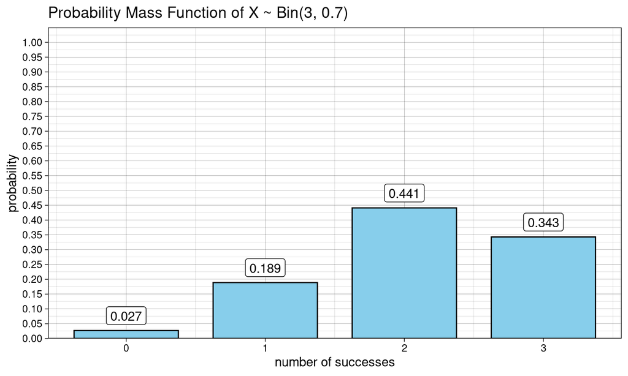

## Graphical Form of the CDF

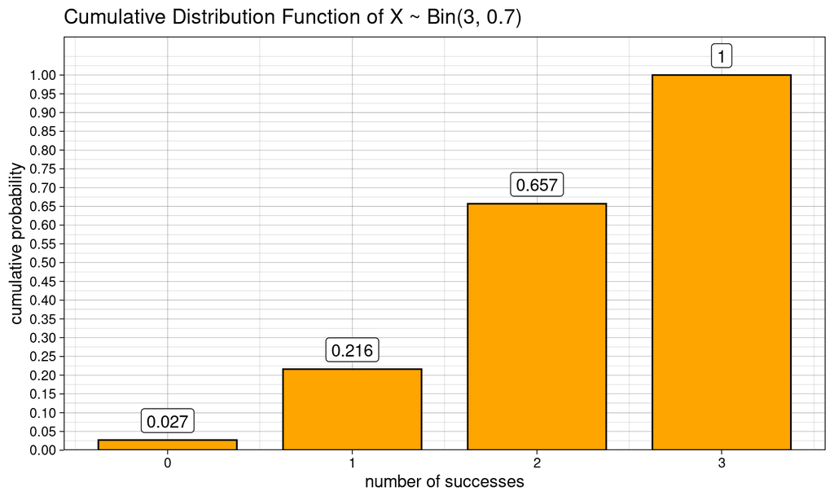

Graphically, the pmf probabilities “stack up” to make the CDF. Geometrically, probabilities are proportional rectangles—the same width, but different heights.

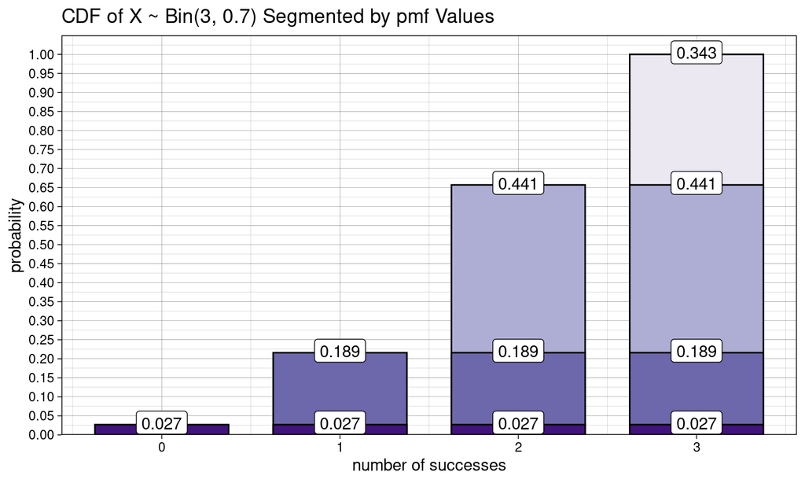

## Mean and Variance

## E[X] and Var[X]

The expected (mean) number of successes and the variance of the number of successes are found as follows. You can explore the proof [**HERE**](https://www.probabilisticworld.com/binomial-distribution-mean-variance-formulas-proof/). In general:

\[E[X] = \mu = \sum\limits_{x} x f(x) = \sum\limits_{x} x {n \choose x}p^x(1-p)^{n-x}\]

\[Var[X]=\sigma^2=\sum\limits_{x} (x-\mu)^2f(x)\]

For the binomial distribution, these equations simplify to:

\[E[X] = np\]

\[Var[X] = np(1-p)\]

## E[X] and Var[X] for Our Coins

The expected value of our biased coin is the *long-run* average number of heads over \(\infty\) repetitions of 3 flips. For a binomial variable, E[X] may not an integer, even though \(x\) must be.

```r
n <- 3
p <- 0.7
n * p   # expected value
```

```
[1] 2.1
```

```r
n * p * (1 - p)   # variance, take square root for SD
```

```
[1] 0.63
```

Can you calculate the E[X] and Var[X] for 3 flips of the fair coin?